# Data Visualization with ggplot2

Scott Stoltzman

5/15/2019

## # Homework - Data Visualization

#### Tidy Tuesday with ggplot2

In this assignment you will take data given from the `student_ratio` variable below and make relevant charts from it. Reading the data into R has been taken care of for you, but the visualization is up to you!

You are also responsible for completing all “Exercises” in Chapter 3 of R for Data Science.

| edulit_ind | indicator | country_code | country | year | student_ratio | flag_codes | flags |
| --- | --- | --- | --- | --- | --- | --- | --- |
| PTRHC_2 | Lower Secondary Education | MRT | Mauritania | 2013 | 56.59395 | NA | NA |
| PTRHC_2 | Lower Secondary Education | MRT | Mauritania | 2014 | 51.94690 | NA | NA |
| PTRHC_2 | Lower Secondary Education | MRT | Mauritania | 2015 | 53.22717 | NA | NA |
| PTRHC_2 | Lower Secondary Education | MRT | Mauritania | 2016 | 38.18923 | NA | NA |
| PTRHC_1 | Primary Education | COD | Democratic Republic of the Congo | 2012 | 34.74758 | NA | NA |
| PTRHC_1 | Primary Education | COD | Democratic Republic of the Congo | 2013 | 37.06925 | NA | NA |

### Visualize student_ratio across all countries for all years using a histogram!

Below, you need to add something after `geom_` in order to create a histogram. What do you need to add?

**Ignore** any warnings for now!

```
## Warning: Removed 325 rows containing non-finite values (stat_bin).
```

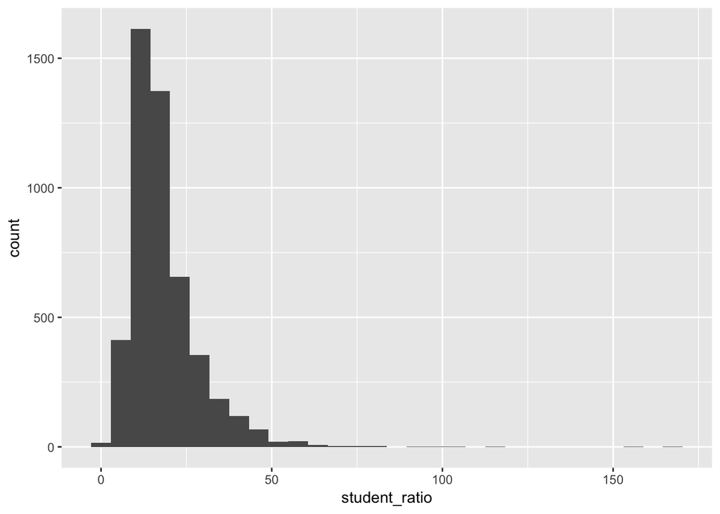

### Visualize average Primary Education student_ratio in the USA over the years with a line chart.

Hint, I have already filtered the data for you, just create a line!

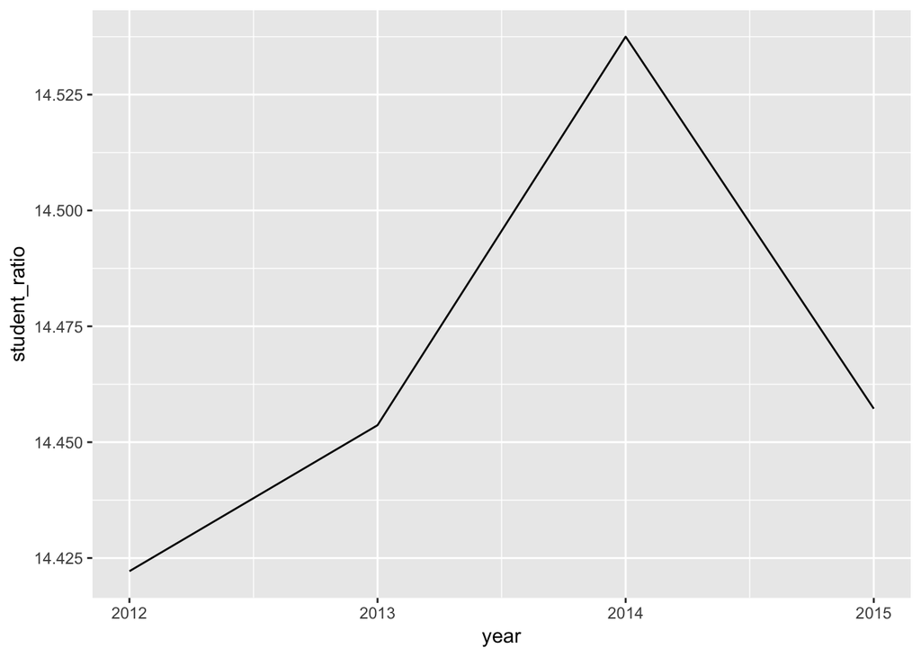

### Visualize student_ratio of each indicator (Primary, Secondary, etc.) in the USA over the years with a line chart. Utilize colors to differentiate between the different indicators.

Hint, I have already filtered the data for you, just create a line (similar to the one above) and add colors.

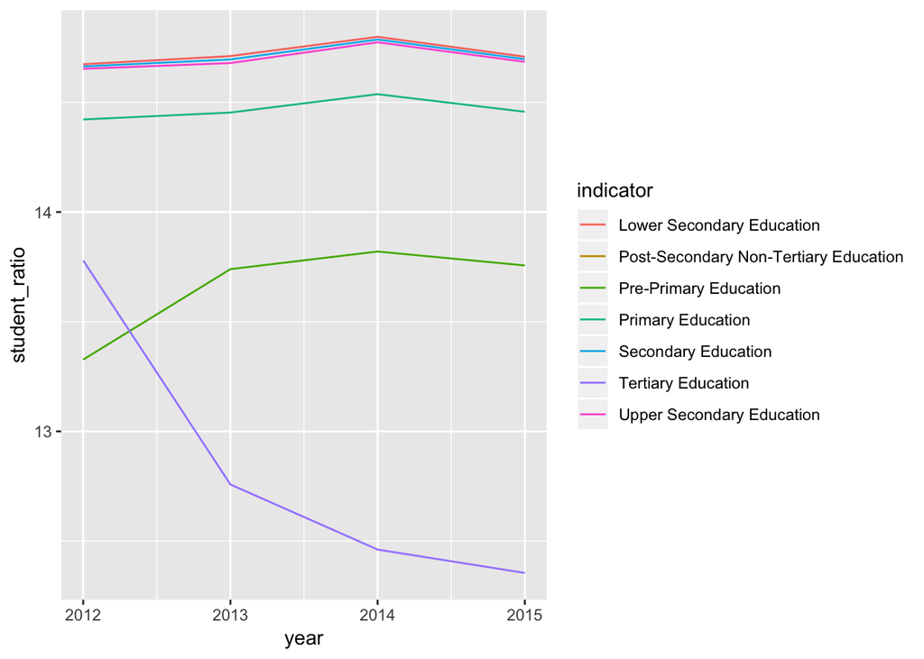

### Visualize a bar plot of the different levels student_ratio by country for Primary Education in 2015 by country (of the top 10 biggest student_ratio)

Hint, data is filtered for you

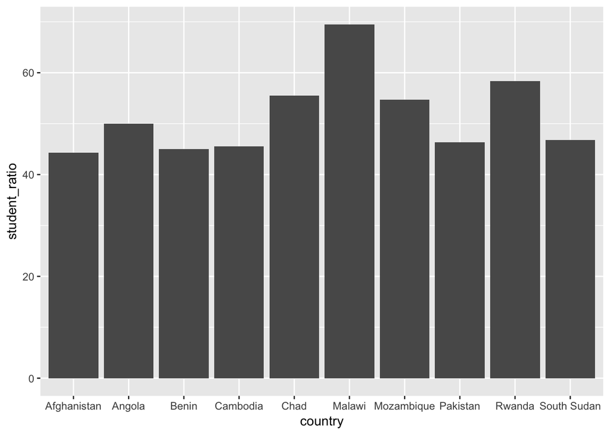

#### Flip the plot above on its side and sort it from high to low (highest on top)

Hint, we will just continue to use the `filtered_data` from the previous cell

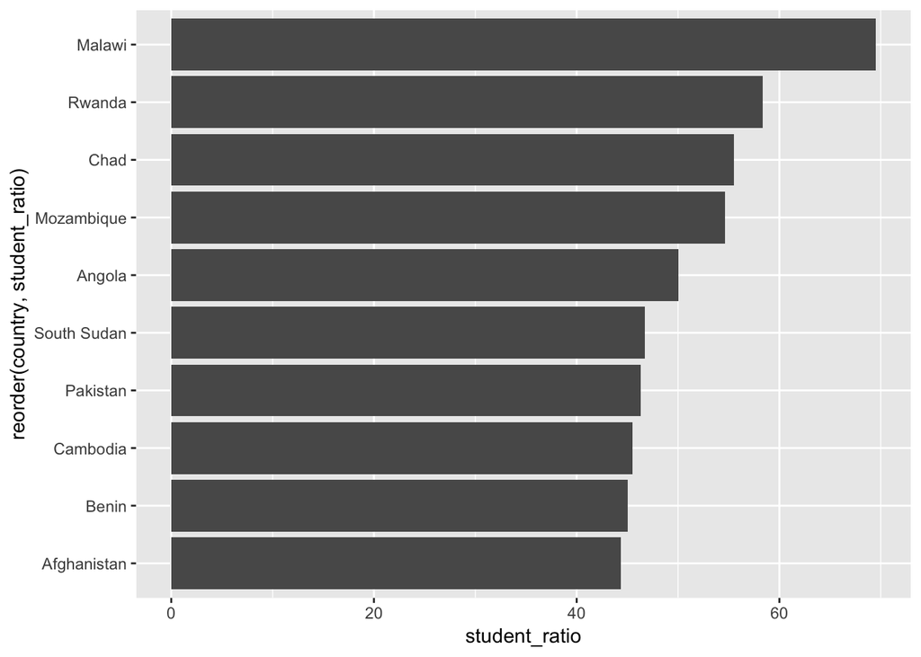